# My Simple Logistic Regression

[figure not shown]

Gender and Alcohol Analysis

## Background

In this analysis, I want to estimate the probability for a male adult, specifically an inpatient recruited in the detoxification unit, to know whether a man tends to be more alcoholic (consuming more than 14 drinks per day) than a female or not.

The dataset has a list of people indicating their sex and the daily drinks of alcohol they reported to be consuming.

$$H_0: \beta_1 = 0 \\
H_a: \beta_1 \neq 0$$
In other words, if $\beta_1$ is $Male$, then the number of Alcohol drinks males and females drink have no insight about the probability to be an alcoholic.

```r
HELPrct = HELPrct %>%
  select(c("sex", "i1"))
sexDrink <- glm(sex ~ i1, data = HELPrct, family=binomial)
# Table Summary
datatable(HELPrct, options=list(lengthMenu = c(10)), extensions="Buttons")
```

|  | sex | i1 |
| --- | --- | --- |
| 1 | male | 13 |
| 2 | male | 56 |
| 3 | male | 0 |
| 4 | female | 5 |
| 5 | male | 10 |
| 6 | female | 4 |
| 7 | female | 13 |
| 8 | male | 12 |
| 9 | female | 71 |
| 10 | male | 20 |

[output cut: 443 more lines]

## Analysis

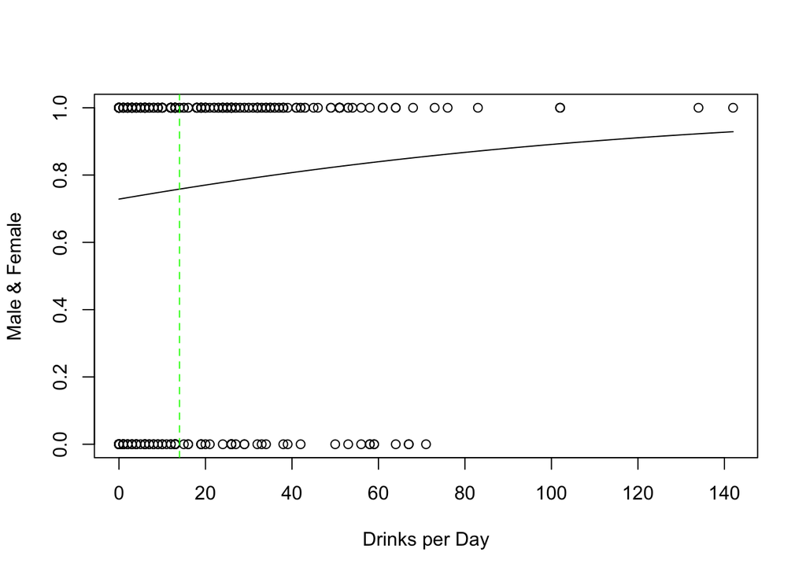

```r
# plot
plot(sex=="male" ~ i1, data=HELPrct, xlab = "Drinks per Day", ylab = "Male & Female")
b <- coef(sexDrink)
curve(exp(b[1] + b[2]*x)/(1 + exp(b[1] + b[2]*x)), add = TRUE)
abline(v=14, lty=2, col="green")
```

The probability for an alcoholic to be a male is giving in the Logistic Model using the General Linear Model, which values are as following:

```r
(summary(sexDrink)) %>% pander
```

|  | Estimate | Std. Error | z value | Pr(>\|z\|) |
| --- | --- | --- | --- | --- |
| **(Intercept)** | 0.9871 | 0.1491 | 6.619 | 3.611e-11 |
| **i1** | 0.01114 | 0.006376 | 1.747 | 0.08071 |

(Dispersion parameter for binomial family taken to be 1 )

| Null deviance: | 495.3 on 452 degrees of freedom |
| --- | --- |
| Residual deviance: | 491.9 on 451 degrees of freedom |

From the analysis, we obtain a $P-Value$ of $0.08071$ which is high enough to fail to reject the null hypothesis.

## Conclusion

After this analysis, we can finally conclude that we do not have sufficient evidence to reject the null hypothesis, meaning that we do not have sufficient evidence to assume that the sex of an individual at the detoxification unit has a relation with the number of drinks they consume, much less if they are alcoholics or not.